# NYPD Shooting: Multi-victim Incidents

Ron Sielinski

2024-05-16

## Step 1: Start an Rmd Document

The first step involves creating this R markdown document and importing the New York City’s shooting data set in a reproducible manner.

We start by loading the tidyverse package, which contains multiple functions that will simplify most of the tasks involved in this analysis. For example, the `read_csv()` function allows us to import the data directly from the City of New York, which makes its data freely available at https://data.cityofnewyork.us.

```r
# set warning and messages equal to FALSE to keep them from showing up in the doc.

library(tidyverse)

# load data from the City of New York
data_file <- 'https://data.cityofnewyork.us/api/views/833y-fsy8/rows.csv?accessType=DOWNLOAD'
ny_dat <- read_csv(data_file)
```

## Step 2: Tidy and Transform the Data

Next, we profile the data to understand what the data set contains and to identify question(s) that we want to answer.

```r
# display a high-level summary of the data
summary(ny_dat)
```

```
##   INCIDENT_KEY        OCCUR_DATE         OCCUR_TIME           BORO
##  Min.   :  9953245   Length:28562       Length:28562      Length:28562
##  1st Qu.: 65439914   Class :character   Class1:hms        Class :character
##  Median : 92711254   Mode  :character   Class2:difftime   Mode  :character
##  Mean   :127405824                      Mode  :numeric
##  3rd Qu.:203131993
##  Max.   :279758069
##
##  LOC_OF_OCCUR_DESC     PRECINCT     JURISDICTION_CODE LOC_CLASSFCTN_DESC
##  Length:28562       Min.   :  1.0   Min.   :0.0000    Length:28562
##  Class :character   1st Qu.: 44.0   1st Qu.:0.0000    Class :character
##  Mode  :character   Median : 67.0   Median :0.0000    Mode  :character
##                     Mean   : 65.5   Mean   :0.3219
##                     3rd Qu.: 81.0   3rd Qu.:0.0000
##                     Max.   :123.0   Max.   :2.0000
##                                     NA's   :2
##  LOCATION_DESC      STATISTICAL_MURDER_FLAG PERP_AGE_GROUP
##  Length:28562       Mode :logical           Length:28562
##  Class :character   FALSE:23036             Class :character
##  Mode  :character   TRUE :5526              Mode  :character
##
##
##
##
##    PERP_SEX          PERP_RACE         VIC_AGE_GROUP        VIC_SEX
##  Length:28562       Length:28562       Length:28562       Length:28562
##  Class :character   Class :character   Class :character   Class :character
##  Mode  :character   Mode  :character   Mode  :character   Mode  :character
##
##
##
##
##    VIC_RACE           X_COORD_CD        Y_COORD_CD        Latitude
##  Length:28562       Min.   : 914928   Min.   :125757   Min.   :40.51
##  Class :character   1st Qu.:1000068   1st Qu.:182912   1st Qu.:40.67
##  Mode  :character   Median :1007772   Median :194901   Median :40.70
##                     Mean   :1009424   Mean   :208380   Mean   :40.74
##                     3rd Qu.:1016807   3rd Qu.:239814   3rd Qu.:40.82
##                     Max.   :1066815   Max.   :271128   Max.   :40.91
##                                                        NA's   :59
##    Longitude        Lon_Lat
##  Min.   :-74.25   Length:28562
##  1st Qu.:-73.94   Class :character
##  Median :-73.92   Mode  :character
##  Mean   :-73.91
##  3rd Qu.:-73.88
##  Max.   :-73.70
##  NA's   :59
```

To do that, we need know what the individual columns in the data set tell us about the shootings. Fortunately, the city also publishes a guide to the data: https://data.cityofnewyork.us/Public-Safety/NYPD-Shooting-Incident-Data-Historic-/833y-fsy8/about_data. From that, we learn that the first column, INCIDENT_KEY, is a persistent identifier for each shooting incident.

A quick query confirms that an individual incident can have multiple victims.

```r
# for my convenience, convert column names to lower case (to make typing easier)
colnames(ny_dat) <- colnames(ny_dat) %>%
  str_to_lower()

# display the number of shooting records per unique incident
ny_dat %>%
  group_by(incident_key) %>%
  summarize(cnt = n()) %>%
  ungroup() %>%
  arrange(desc(cnt))
```

```
## # A tibble: 22,394 × 2
##    incident_key   cnt
##           <dbl> <int>
##  1    173354054    18
##  2    263503175    16
##  3     23749375    12
##  4     24717013    12
##  5     33478089    12
##  6     33706902    12
##  7     35803777    12
##  8     66027258    12
##  9     72195829    12
## 10     72616285    12
## # ℹ 22,384 more rows
```

In fact, one incident had 18 victims! However, there is only one 18-victim incident out of more than 22k, which raises a number questions about multi-victim incidents.

To further simplify analysis, we’ll reduce the data set to the columns that we’re likely need: incident_key, occur_date, and statistical_murder_flag. To facilitate a variety of perspectives, we’ll change the occur_date from a character to a date and introduce month_name as a factor.

```r
# keep only fields needed to analyze multi-victim incidents
ny_dat <- ny_dat %>%
  select(incident_key, occur_date, statistical_murder_flag)

# convert the date field from a character data type to a date
ny_dat$occur_date <- mdy(ny_dat$occur_date)

# coarsen granularity of the occurrence date to monthly and yearly to simplify
# analysis and visualizations
ny_dat <- ny_dat %>%
  mutate(occur_year = year(occur_date),
         occur_month = floor_date(occur_date, unit = 'month'),
         calendar_month = month(occur_date),
         month_name = factor(month.name[calendar_month], levels = month.name)
  )
```

Summarizing the data again confirms that the reduced data set is complete: None of columns in the reduced data set has missing data.

```r
# display a high-level summary of the data
summary(ny_dat)
```

```
##   incident_key         occur_date         statistical_murder_flag
##  Min.   :  9953245   Min.   :2006-01-01   Mode :logical
##  1st Qu.: 65439914   1st Qu.:2009-09-04   FALSE:23036
##  Median : 92711254   Median :2013-09-20   TRUE :5526
##  Mean   :127405824   Mean   :2014-06-07
##  3rd Qu.:203131993   3rd Qu.:2019-09-29
##  Max.   :279758069   Max.   :2023-12-29
##
##    occur_year    occur_month         calendar_month       month_name
##  Min.   :2006   Min.   :2006-01-01   Min.   : 1.000   July     : 3390
##  1st Qu.:2009   1st Qu.:2009-09-01   1st Qu.: 5.000   August   : 3264
##  Median :2013   Median :2013-09-01   Median : 7.000   June     : 2959
##  Mean   :2014   Mean   :2014-05-23   Mean   : 6.805   May      : 2682
##  3rd Qu.:2019   3rd Qu.:2019-09-01   3rd Qu.: 9.000   September: 2677
##  Max.   :2023   Max.   :2023-12-01   Max.   :12.000   October  : 2378
##                                                       (Other)  :11212
```

Had there been missing data, there are a number of techniques that we could have used to address the missing data:

- Cross validation: Since individual incidents can have multiple victims, we could check to see if other records from the same incident have the missing data.
- Ignore the missing data: jurisdiction_code, for example, has only 2 records with NA values. Ignoring the NA’s would have minimal impact on most statistical analyses, although that fact would need to be confirmed and called out in any summary/report of the analysis.
- Reclass the missing data: In some cases (e.g, perp_sex), it might be sufficient to reclass the NA’s as “U” (unknown), because, depending on the analysis, NA and “U” might be functionally identical.

## Step 3: Add Visualizations and Analysis

We know that largest number of victims per incident was 18. To get a better understanding at the distribution of victims per incident, we can look at a couple of histograms. First, a count of incidents by the number of victims.

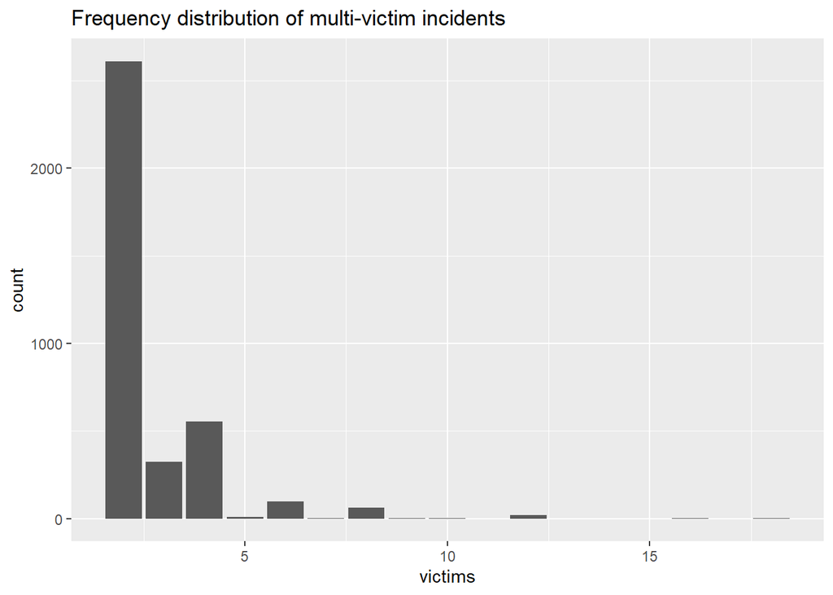

```r
# create a data frame that contains the number of victims and murders per incident
incident_cnts <- ny_dat %>%
  group_by(incident_key) %>%
  summarize(victims = n(), murders = sum(statistical_murder_flag)) %>%
  ungroup() %>%
  filter(victims > 1)

# look at the frequency distribution of multi-victim incidents
incident_cnts %>%
  ggplot() +
  geom_histogram(aes(x = victims), stat = 'count') +
  labs(title = 'Frequency distribution of multi-victim incidents')
```

Similarly, a count of incidents by the number of murders.

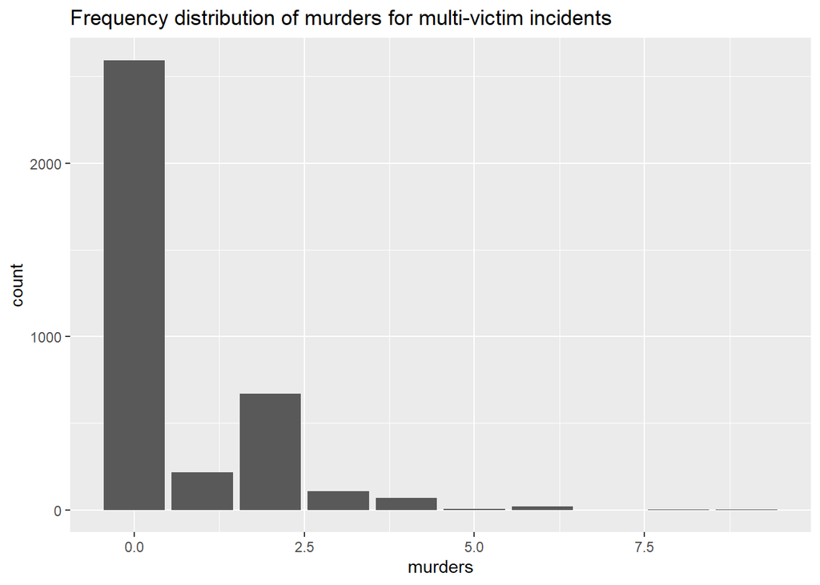

```r
# look at the frequency distribution of murders for multi-victim incidents
incident_cnts %>%
  ggplot() +
  geom_histogram(aes(x = murders), stat = 'count') +
  labs(title = 'Frequency distribution of murders for multi-victim incidents')
```

The most frequent number of murders is zero, which raises a new question: What is the typical number of murders per multi-victim incident?

```r
# average number of murders per shooting
simple_mean <- sum(incident_cnts$murders) / sum(incident_cnts$victims)
print(simple_mean)
```

```
## [1] 0.2356164
```

The global average for the murders-to-victims ratio is 0.24.

Averages can be deceiving, however. In fact, a model that estimates the number of murders based on that average would perform poorly. The following chart shows that, in most cases, an average-based model either over-estimates or under-estimates the murders-to-victims ratios.

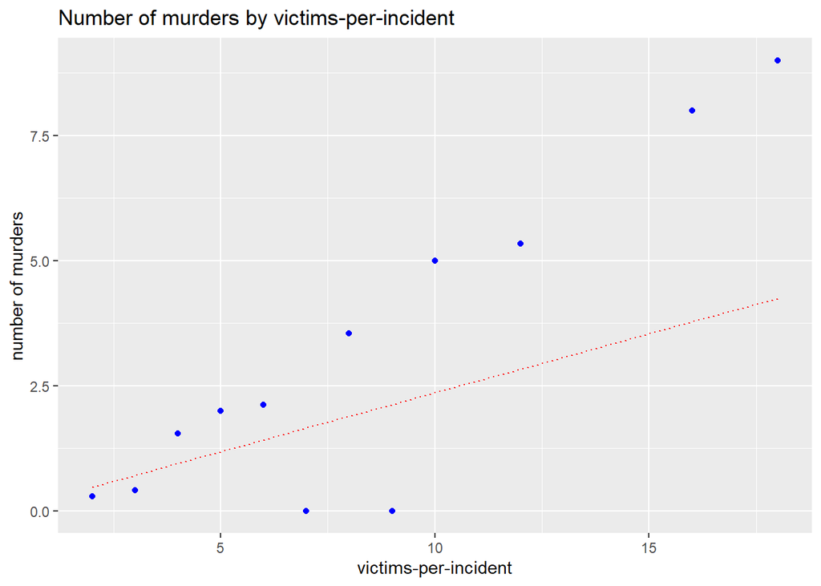

```r
# calculate the actual ratio of murders-to-victims based on the number of
# victims-per-incident
murder_ratio <- incident_cnts %>%
  group_by(victims) %>%
  summarize(incidents = n(), mean_murders = mean(murders)) %>%
  ungroup() %>%
  mutate(murder_ratio = mean_murders / victims)

# use the simple_mean to predict the number of murders
murder_ratio$simple_mean <- simple_mean * murder_ratio$victims

# plot the difference between the actual and predicted number of murders
ggplot(murder_ratio, aes(x = victims)) +
  geom_point(aes(y = mean_murders), color = 'blue') +
  # add the average model
  geom_line(aes(y = simple_mean), color = 'red', linetype = 'dotted') +
  labs(title = 'Number of murders by victims-per-incident',
       y = 'number of murders',
       x = 'victims-per-incident')
```

The reason is that the murders-to-victims ratio changes with the number of victims. The following chart illustrates the point:

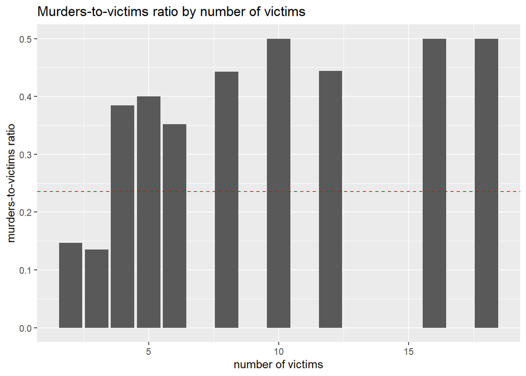

```r
# plot the murders-to-victims ratio
ggplot(murder_ratio) +
  geom_col(aes(x = victims, y = murder_ratio)) +
  # show the average murder ratio as a dashed red line
  geom_hline(yintercept = simple_mean, color = 'red', linetype = 'dashed') +
  labs(title = 'Murders-to-victims ratio by number of victims',
       x = 'number of victims',
       y = 'murders-to-victims ratio')
```

Because most multi-victims incidents involve only 2 victims, they have the most influence on the calculation of the average.

As such, a model that incorporates the number of victims per incident would produce more accurate results.

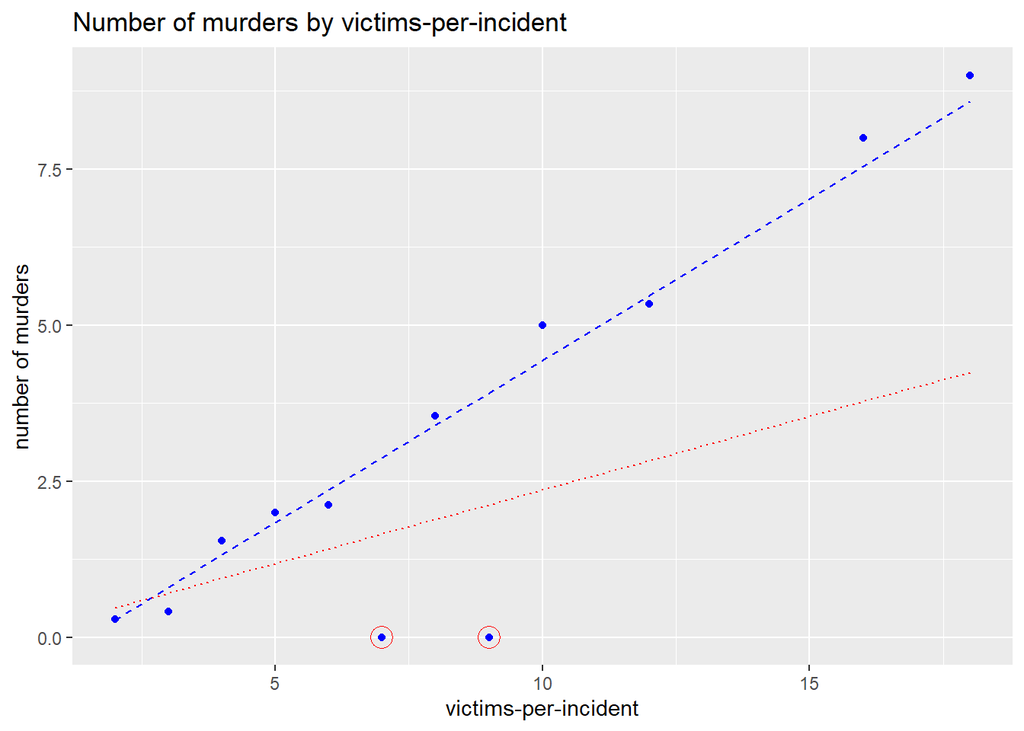

```r
# build a model to predict the number of murders based on victims-per-incident
lm_fit <- lm(murders ~ victims, data = select(incident_cnts, murders, victims))

# use the model to predict the number of murders
murder_ratio$predicted <- predict(lm_fit, newdata = murder_ratio)

# plot the difference between the actual and predicted number of murders
ggplot(murder_ratio, aes(x = victims)) +
  geom_point(aes(y = mean_murders), color = 'blue') +
  # add the linear model
  geom_line(aes(y = predicted), color = 'blue', linetype = 'dashed') +
  # add the average model
  geom_line(aes(y = simple_mean), color = 'red', linetype = 'dotted') +
  # emphasize the outliers
  geom_point(
    data = filter(murder_ratio, mean_murders == 0),
    aes(y = mean_murders),
    color = 'red',
    shape = 1,
    size = 5
  ) +
  labs(title = 'Number of murders by victims-per-incident',
       y = 'number of murders',
       x = 'victims-per-incident')
```

The chart above shows that a simple linear model is much more accurate.

### Potential Sources of Bias

There are multiple other sources of bias:

- This analysis looks at the number of murders per incident. However, the definition of “murder” is not clear. For example, does it depend on an admission of guilty or the verdict of jury? Would the historic count of murders change if the perpetrator was eventually acquitted? Is manslaughter handled any differently (or not counted at all)? A clear definition of murder is important for both the analysis and the interpretation of results.
- The online guide to the data specifically refers to the INCIDENT_KEY as a “randomly generated persistent ID for each arrest”. That suggests that an incident might be included in the data only if the perpetrator was arrested. That might make the analysis blind to incidents were an arrest did *not* occur.
- My personal bias had a definite effect on this analysis. I have long been leery of summary statistics (like mean), especially when they can lead to mistaken conclusions about data. In this case, that bias has resulted in my directing the analysis to a result that confirms my bias. I might have mitigated that by intentionally focusing on a different aspect of the shooting incident data, because the assignment was open-ended, and I had the freedom to explore it from multiple perspectives.

## Conclusion

An initial exploration of NYPD Shootings involved summarizing and transforming the data to better understand its structure and contents. This led to a focus on multi-victim incidents and their murder rates.

The importance of this insight was illustrated by showing the difference in accuracy between models that predict the average number of murders using 1) a global average and 2) averages based on the number of victims per incident.